# Homework 3

Heath Blackmon

2/1/2018

# Reading in the data

The first thing that we need to do is read in all of the data:

```r
dat.m <- read.csv("gnatocerus.male.csv")
dat.f <- read.csv("gnatocerus.female.csv")
```

# Difference in males and females

Now just to get a feel for things lets plot the body size observations for males and females on the same plot.

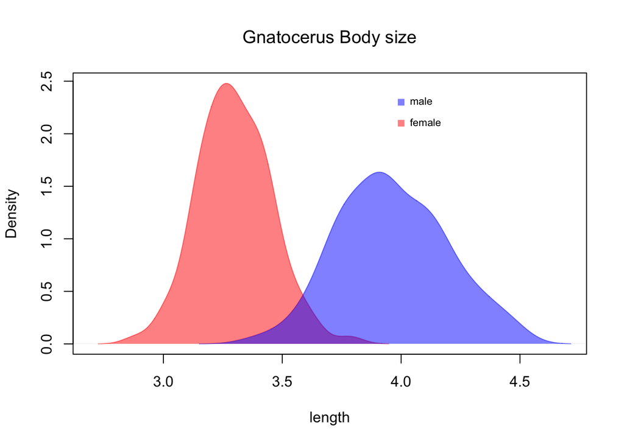

```r
b.m <- density(dat.m$body)
b.f <- density(dat.f$body)
plot(b.f,xlim=c(2.7,4.7),col=rgb(1,0,0,.5),
     main="Gnatocerus Body size", xlab="length")
lines(b.m,col=rgb(0,0,1,.5))
polygon(b.f,col=rgb(1,0,0,.5),border=NA)
polygon(b.m,col=rgb(0,0,1,.5),border=NA)
points(x=4, y=2.3, pch=15, col=rgb(0,0,1,.5))
points(x=4, y=2.1, pch=15, col=rgb(1,0,0,.5))
text(x=4, y=2.3, pos=4, "male", cex=.7)
text(x=4, y=2.1, pos=4, "female", cex=.7)
```

# Are horns and body size correlated?

We are really interested in horn length in males because we think it may be a sexually antagonistic trait. Lets make a plot with horn size as a function of body size.

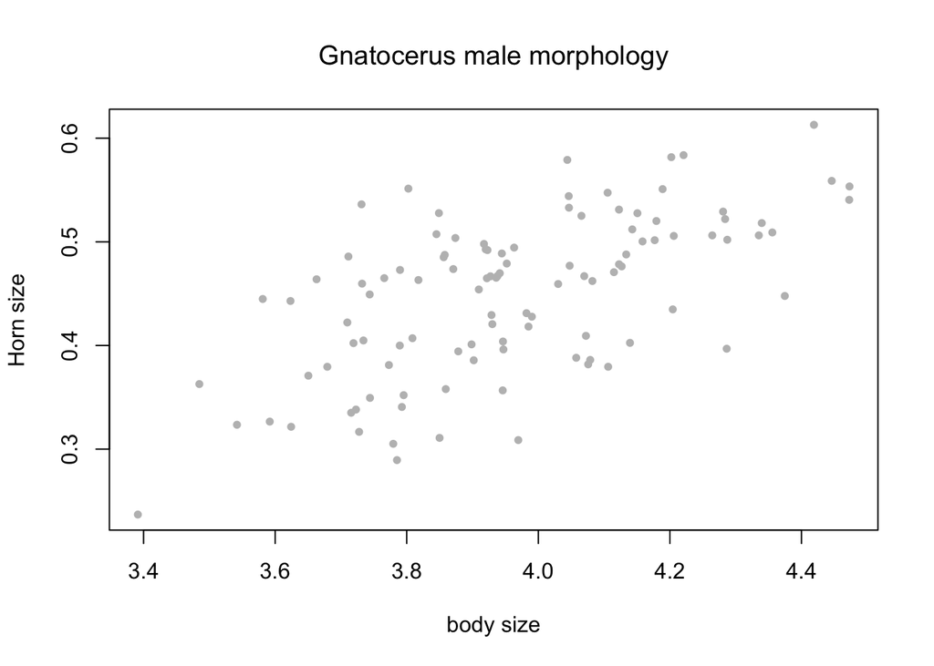

```r
plot(dat.m$horn ~ dat.m$body,
     pch = 16, col = "gray",
     cex = .8, main="Gnatocerus male morphology",
     ylab="Horn size", xlab="body size")
```

That looks like a pretty strong correlation. Lets test its significant using the R function `cor.test`.

```r
cor.test(dat.m$horn, dat.m$body)
```

```
##
##  Pearson's product-moment correlation
##
## data:  dat.m$horn and dat.m$body
## t = 7.8945, df = 105, p-value = 2.978e-12
## alternative hypothesis: true correlation is not equal to 0
## 95 percent confidence interval:
##  0.4755485 0.7170744
## sample estimates:
##       cor
## 0.6103045
```

This is a fairly strong correlation. When we see something like this one thing that can often help is to take the size of the trait after correcting for the variable that you think may be creating the correlation. In this case I believe that when a beetle grows large all of its body parts are more likely to be large - including the horns. We can do a regression (which we will study in more depth soon) to extract the relative size of the horn after correcting for body size.

```r
# lm stands for linear model and in this case will fit a
# least squares regression.  The [[2]] at the end is getting
# it to only return the second item which is the residuals.
horns.resid <- lm(dat.m$horn ~ dat.m$body)[[2]]
```

Lets add this to our data table:

```r
# cbind just allows us to bind another column to our dataframe
dat.m <- cbind(dat.m, horns.resid)
```

Now lets do a series of cor.tests to see what the relationship between mating attempts and grandchildren look like.

```r
cor.test(dat.m$mating.attempts, dat.m$body)
```

```
##
##  Pearson's product-moment correlation
##
## data:  dat.m$mating.attempts and dat.m$body
## t = 3.1238, df = 105, p-value = 0.002308
## alternative hypothesis: true correlation is not equal to 0
## 95 percent confidence interval:
##  0.1077077 0.4562045
## sample estimates:
##       cor
## 0.2916031
```

```r
cor.test(dat.m$mating.attempts, dat.m$horn)
```

```
##
##  Pearson's product-moment correlation
##
## data:  dat.m$mating.attempts and dat.m$horn
## t = 3.7149, df = 105, p-value = 0.0003277
## alternative hypothesis: true correlation is not equal to 0
## 95 percent confidence interval:
##  0.1614169 0.4984350
## sample estimates:
##       cor
## 0.3408301
```

```r
cor.test(dat.m$mating.attempts, dat.m$horns.resid)
```

```
##
##  Pearson's product-moment correlation
##
## data:  dat.m$mating.attempts and dat.m$horns.resid
## t = 2.1527, df = 105, p-value = 0.03363
## alternative hypothesis: true correlation is not equal to 0
## 95 percent confidence interval:
##  0.01637296 0.38059477
## sample estimates:
##       cor
## 0.2055923
```

As we might expect since they are correlated both horn size and body size show a similar result. Interestingly so does the residual of horn size after correcting for body size. We might be a bit surprised by this and it suggests that even ignoring overall body size beetles with longer horns for their size have an advantage over beetles with smaller horns for their size. We might want to visualize these relationships side by side with a plot showing mating attempts as a function of body size and as a function of horn residual.

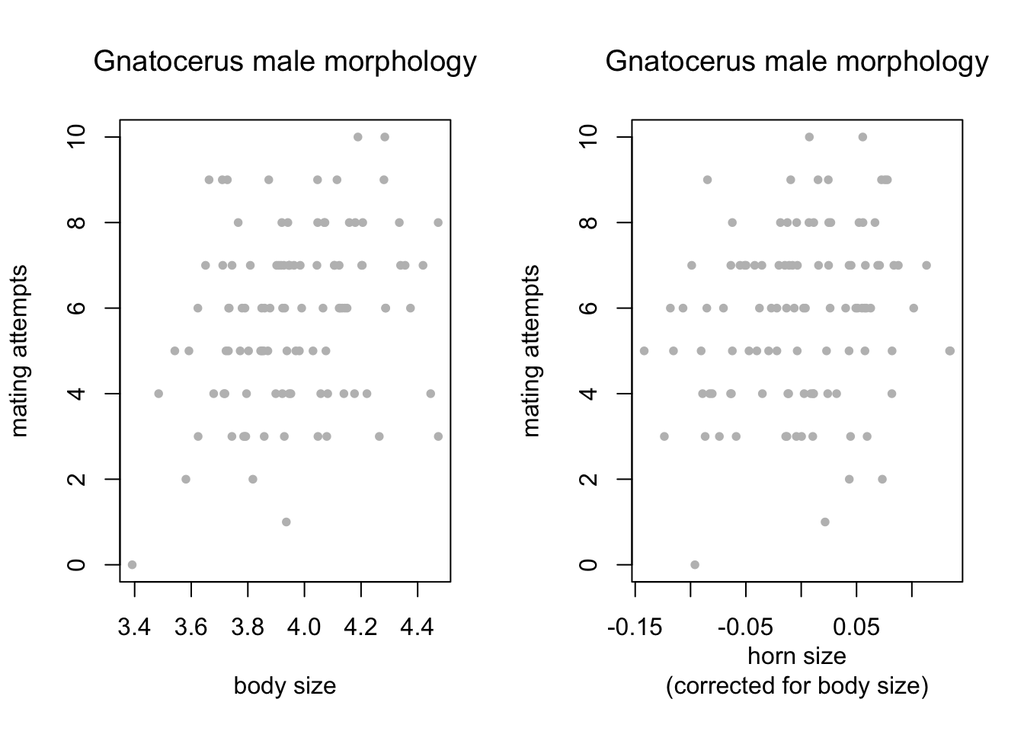

```r
# this code splits our plot area into two columns
par(mfcol=c(1,2))

#first we plot the body size
plot(dat.m$mating.attempts ~ dat.m$body,
     pch = 16, col = "gray",
     cex = .8, main="Gnatocerus male morphology",
     ylab="mating attempts", xlab="body size")

#now we plot the horn residual size
plot(dat.m$mating.attempts ~ dat.m$horns.resid,
     pch = 16, col = "gray",
     cex = .8, main="Gnatocerus male morphology",
     ylab="mating attempts", xlab="horn size\n(corrected for body size)")
```

# Predictors of a males grandchildren

Lets now examine the relationship with grandchildren

```r
cor.test(dat.m$grandchildren, dat.m$body)
```

```
##
##  Pearson's product-moment correlation
##
## data:  dat.m$grandchildren and dat.m$body
## t = 1.7465, df = 105, p-value = 0.08365
## alternative hypothesis: true correlation is not equal to 0
## 95 percent confidence interval:
##  -0.02255958  0.34681363
## sample estimates:
##       cor
## 0.1680185
```

```r
cor.test(dat.m$grandchildren, dat.m$horn)
```

```
##
##  Pearson's product-moment correlation
##
## data:  dat.m$grandchildren and dat.m$horn
## t = 0.39221, df = 105, p-value = 0.6957
## alternative hypothesis: true correlation is not equal to 0
## 95 percent confidence interval:
##  -0.1527193  0.2264620
## sample estimates:
##        cor
## 0.03824811
```

```r
cor.test(dat.m$grandchildren, dat.m$horns.resid)
```

```
##
##  Pearson's product-moment correlation
##
## data:  dat.m$grandchildren and dat.m$horns.resid
## t = -0.83442, df = 105, p-value = 0.4059
## alternative hypothesis: true correlation is not equal to 0
## 95 percent confidence interval:
##  -0.2669081  0.1103970
## sample estimates:
##         cor
## -0.08116258
```

In this case none are significant. The most extreme relationship was found in the comparison of grandchildren and body size. Lets look at that one in females.

```r
cor.test(dat.f$offspring, dat.f$body)
```

```
##
##  Pearson's product-moment correlation
##
## data:  dat.f$offspring and dat.f$body
## t = 3.3693, df = 105, p-value = 0.001055
## alternative hypothesis: true correlation is not equal to 0
## 95 percent confidence interval:
##  0.1302191 0.4740979
## sample estimates:
##       cor
## 0.3123551
```

# Female body size and offspring

In contrast to what we see in males females have a fairly strong positive correlation between body size and offspring count. Lets look at some plots to show these two different relationships.

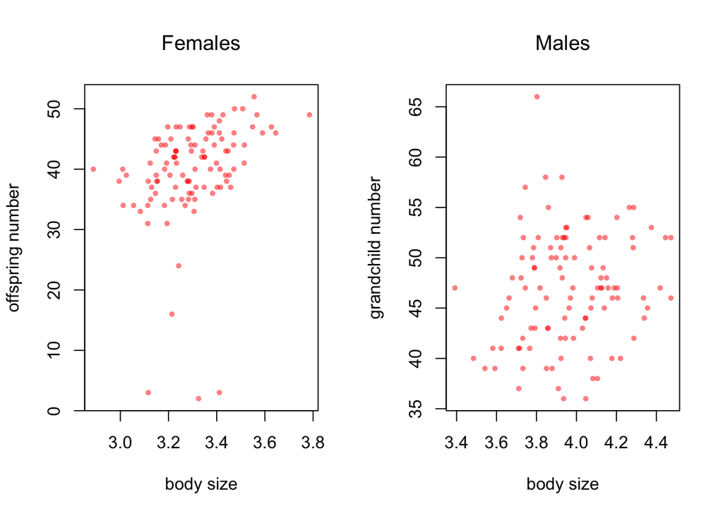

```r
par(mfcol=c(1,2))
plot(dat.f$offspring ~ dat.f$body,main="Females",
     xlab="body size", ylab="offspring number",
     pch=16, cex=.7, col=rgb(1,0,0,.5))
plot(dat.m$grandchildren ~ dat.m$body,main="Males",
     xlab="body size", ylab="grandchild number",
     pch=16, cex=.7, col=rgb(1,0,0,.5))
```

When we look at the females we see that our data actually include 3 individuals that have close to zero offspring. These were actually beetles that died during the time that they were being monitored. For this reason we could remove them but the relationship is strong enough that it holds even when we retain them.

# Thoughts about homework questions

1. What is the impact of having a larger body, is it different for males and females? *The last two figures and the correlation tests answer this question quite clearly for females. However, the picture in males is a little more complicated - you can consider both the way that body size impacts number of mating attempts and the number offspring that are produced by his daughters.*
2. What are the best predictors for number of mating attempts and the number of grandchildren a male will produce? *These can be answered with correlation tests and scatter plots using the `plot` funciton.*